# Using a historical ecology approach to describe algal community change

Neushul Revisited

Ross Whippo

Created: 2021-05-07 ; (Updated: 2021-06-18)

# 1 Background

Algae are the primary trophic resource in many near-shore habitats, and climate change is rapidly altering these communities (Krumhansl et al. 2016; Duarte et al. 2018). It’s important to contextualize surveys with some sort of historical baseline, but comprehensive historical surveys of the benthos are often hard to find. If such historical data is found, it can be a valuable tool for uncovering the structure and trajectory of communities (Carnell and Keough 2019; Lindenmayer et al. 2012). In addition, baselines shift through time, altering our expectation of how communities might change in the future (Magurran et al. 2010; Dayton et al. 1998). More complexities arise when considering that methods for data collection change through time. Modern tools allow us to collect ever larger quantities of data with more detail that may not be comparable with historic methods. As such, is difficult to find historical ecological data in the marine realm that is directly comparable to modern data collection.

Fortunately, one such data set was published in 1967 in Ecology by M. Neushul entitled ‘Studies of Subtidal Marine Vegetation in Western Washington’ (Neushul 1967). This paper provides a detailed account of algal benthic cover along 12 subtidal transects in the San Juan Islands, and utilized many methods still employed by modern marine ecologists including underwater cameras and traditional slate and pencil data collection.

The goal of this study is to replicate Neushul’s study and collect data in a similar manner so that a direct comparison can be made between the current state of algal communities in the San Juan Islands, and a historical baseline that is deeper than most other quantitative data sets we have from that time period. They began their transects in June of 1962, and if the timeline put forth in this proposal is followed, our data collection will be almost exactly 60 years after.

```r
# Import all data and manage for analyses/visualizations

# site details extracted
site_deets <- read_csv("data/extraction/NeushulSiteDetailsPreplan.csv")

# data from table 1
Table_1 <- read_csv("data/extraction/Neushul_Table_1.csv")

# data from cross-section figures
x_sections <- read_csv("data/extraction/Neushul_Xsection_data-extractions.csv",
                       col_types = cols(`table-number` = col_character(),
                                        transect = col_character()))

# list of algae from algae base scraping
algae_list <- read_csv("algae_list.csv")
```

# 2 Approach

This study has three main components: historical data extraction/pilot data collection; primary field collection; and synthesis. Data extraction is further broken into two categories, explicit extraction and calculated extraction. Explicit extraction is the scraping of published values within the paper (e.g.: transect depths, lengths, cluster analysis values, etc.). Calculated extraction are those values that must be inferred or calculated seperately from implicit data embedded within the paper (e.g.: GPS coordinates from maps, abundance calculations, etc.). Calculated extraction also includes those summaries or visualzations that we are able to create from extracted data not included in the orgininal paper (e.g.: diversity metrics, summary statistics, new clustering models, etc.).

Figure 1: Map of Friday Harbor with beginning of original Neushul transects indicated in red.

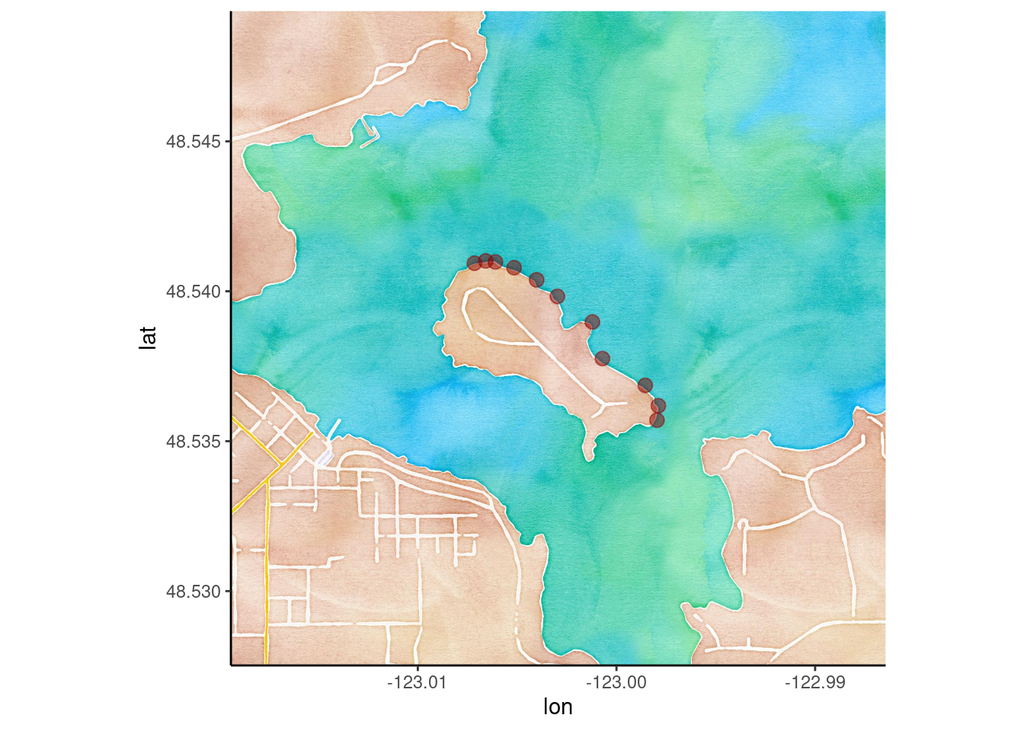

```r
# Map of transect sites

FHL <- get_stamenmap(bbox = c(left = -123.018, bottom = 48.53, right = -122.99, top = 48.547), maptype = "watercolor", crop = FALSE, force = FALSE, zoom = 16)
ggmap(FHL) +
  geom_point(aes(x = longitude, y = latitude), data = site_deets,
             alpha = .5, color="darkred", size = 3)
```

## 2.1 Explicit Extraction

Neushul table 1 data was extracted directly by copying out values into a spreadsheet. Transect cross-section data was extracted by mapping a grid over each figure in GIMP, and then keyed out by eye. Cross-section values extracted included: transect segment (ft), transect segment depth (m), substrate type, icon representation of cover (species/group), and cover associated with Neushul table 1 (species/group).

- Already extracted
  - Table 1 data (community components)
  - Figures 6-9 data (transect cross sections)
- To be extracted
  - Figure 2 data (dendrogram cluster distances)
  - Table 2 (dendrogram summary)

Table 1: Data extracted from cross-section figures 6-9.

```r
datatable(x_sections,
         extensions = c('FixedColumns',"FixedHeader"),
          options = list(scrollX = TRUE,
                         paging=TRUE,
                         fixedHeader=TRUE))
```

|  | transect | segment | depth | substrate | icon-ID | table-number | table-ID | notes |
| --- | --- | --- | --- | --- | --- | --- | --- | --- |
| 1 | 27 | 0-10 | 0-3 | rock | Laminaria | 4 | Laminaria spp. |  |
| 2 | 27 | 10-20 | 3-5 | rock | Laminaria | 4 | Laminaria spp. |  |
| 3 | 27 | 20-30 | 5 | rock | Laminaria | 4 | Laminaria spp. |  |
| 4 | 27 | 30-40 | 5-6 | rock | Laminaria | 4 | Laminaria spp. |  |
| 5 | 27 | 40-50 | 6-7 | rock | Laminaria | 4 | Laminaria spp. |  |
| 6 | 27 | 50-60 | 7 | rock | Laminaria | 4 | Laminaria spp. |  |
| 7 | 27 | 60-70 | 7 | rock | Laminaria | 4 | Laminaria spp. |  |
| 8 | 27 | 70-80 | 7-8 | rock \| mud | Laminaria | 4 | Laminaria spp. |  |
| 9 | 27 | 80-90 | 8 | mud | none | 4 | Laminaria spp. |  |
| 10 | 27 | 90-100 | 8 | mud | none | 4 | Laminaria spp. |  |

[output cut: 318 more lines]

## 2.2 Calculated Extraction

Starting GPS points for SCUBA transects were extracted from Figure 1 using Google Earth, and transect heading and length were taken by overlaying map images with compass bearings in GIMP, and referencing individual transect lengths in Figures 6-9. Data extracted will be analysed and transformed to provide additional data not explicity included in the publication. These data include:

- Already extracted
  - Transect GPS (Google Earth)
  - Transect bearings (GIMP)
  - Updated algal taxonomy (algaebase.org)
- To be extracted
  - Algal frequency values (R)
  - Equivalent method for cluster analysis (R)
  - Addition summaries of diversity and overall transect similarity/differences (R)

Table 2: GPS points for transect origins extracted from Figure 1 using Google Earth. Transect length and maximum depth taken from transect cross-section figures.

```r
# list of extracted GPS points from Figure 1
datatable(site_deets)
```

|  | site_number | longitude | latitude | heading_degrees | transect_length_m | transect_max_depth_m | notes |
| --- | --- | --- | --- | --- | --- | --- | --- |
| 1 | 27 | -123.007148178597 | 48.5409361299338 | 330 | 138 | 14 | heading to FHL dive locker |
| 2 | 31 | -123.006581602029 | 48.5410121699591 | 355 | 122 | 18 | heading to pumphouse |
| 3 | 32 | -123.006092832126 | 48.540977414532 | 015 | 83 | 20 |  |
| 4 | 34 | -123.005152463623 | 48.540785699743 | 030 | 71 | 24 |  |
| 5 | 1 | -123.004017379986 | 48.5403805920313 | 035 | 61 | 24 |  |
| 6 | 3 | -123.00297232402 | 48.5398305145593 | 035 | 61 | 20 |  |
| 7 | 7 | -123.001211108224 | 48.5389763534683 | 040 | 74 | 24 |  |
| 8 | 10 | -123.00070617045 | 48.5377554717423 | 040 | 141 | 20 |  |
| 9 | 13 | -122.998551710593 | 48.5368620009476 | 025 | 132 | 26 |  |
| 10 | 33 | -122.997889770748 | 48.5361820854273 | 080 | 46 | 28 |  |

[output cut: 1 more lines]

Table 3: Identified algae from the orginal paper (‘Names’) and information extracted from algaebase.org (‘Updated Taxonomy’). Species with ‘NA’ in updated taxonomy column must be manually verified.

```r
# extract list of genus/species from table 1 and check against database, run rscript first if you don't want to have scraping take place in the markdown
# algae_list <- spp_list_algaebase(Table_1, phyto.name = 'Name', lakename = "",
#                  long = FALSE, write = FALSE)
algae_list_update <- algae_list %>%
  select(Name, genus, species) %>%
  filter(!Name %in% c('Sea urchins', 'Barnacles', 'Hydroids', 'Lichen', 'Diatom crust (see 16 above)', 'Blue-green algae on mud')) %>%
  unite("Updated Taxonomy", genus:species, sep = " ")
datatable(algae_list_update)
```

|  | Name | Updated Taxonomy |
| --- | --- | --- |
| 1 | Fuscus sp. | NA NA |
| 2 | Ulvoids | NA NA |
| 3 | Gloiopeltis furcata | Gloiopeltis furcata |
| 4 | Laminaria spp. | Laminaria NA |
| 5 | Alaria spp. | Alaria NA |
| 6 | Costaria costata | Costaria costata |
| 7 | Zostera marina | Zostera marina |
| 8 | Constantinea subulifera | Constantinea subulifera |
| 9 | Cymathere triplicata | NA NA |
| 10 | Crustose red algae | NA NA |

[output cut: 37 more lines]

## 2.3 Field Pilot

To identify more applicable methods to replicate data gathered in Neushul and to assess the time taken for each transect survey, a limited number of exploratory dives will be made around Brown Island. Between one and three representative transects will be identified from the original paper for this pilot. Dives will be made with the following specific goals (current plan is listed in parenthesis next to each item):

1. Determine best methods for data collection
- laying transect tape (from GPS starting point along heading to depth [buddy 1]; data collected on return)
- video data capture (using Vaquita underwater camera w/ lights; centered on transect line moving shoreward [buddy 2])
- uniform point count data collection (collected every 5 feet along transect: substrate type, all organsims directly above/below line on meter tape [buddy 1])
2. Estimate time needed for field methods
- mean time in minutes for each transect (current estimate ~60 min)
- multiply by number of transects (11 Brown Island transects * 60 min = 660 min)
- identify likely factors that may change times: depth, length (a more realistic number of dives for this data is between 15-20 for all data collection)

## 2.4 Estimated Dives for Primary Field Collections

The pilot data can likely be collected in 3-5 dives. Current estimates of final number of data collection dives will likely be at minimum 15 dives, and probably closer to 20.

## 2.5 Planned Timeline

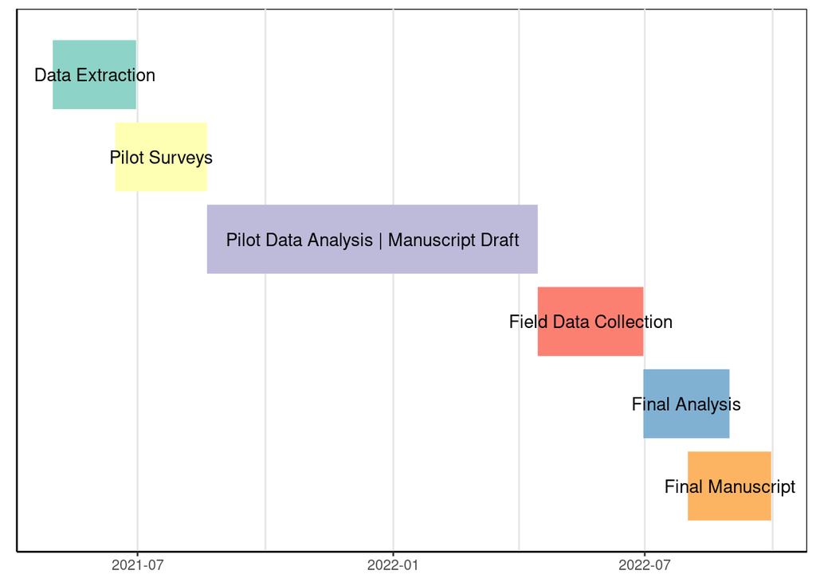

```r
# timeline data
neushul_timeline <- read.csv(text="event,start,end
                       Data Extraction,2021-05-01,2021-06-30
                       Pilot Surveys,2021-06-15,2021-08-20
                       Pilot Data Analysis | Manuscript Draft,2021-08-20,2022-04-15
                       Field Data Collection,2022-04-15,2022-06-30
                       Final Analysis,2022-06-30, 2022-08-31
                       Final Manuscript, 2022-08-01, 2022-09-30")

gg_vistime(neushul_timeline, optimize_y = FALSE, linewidth = 20)
```

# 3 Budget

Current estimates for a two week stay at FHL. Costs for pilot-phase boat time may be covered by boat time already allocated to RW in 2021.

```r
neushul_budget <- read.csv(text=
                      "phase, item, unit, quantity, cost, notes
                      pilot, boat time, hours, 6, 86.00, might be covered by RW
                      main project, housing, weeks, 2, 654.00, FHL 2-bedroom unit
                      main project, facility fee, weeks, 2, 92.00, FHL for 2 people
                      main project, dive fee, year, 1, 210.00, FHL for 2 people
                      main project, EH&S fee, year, 1, 454.00, FHL for 2 people
                      main project, boat time, hours, 40, 86.00, FHL estimate for 20 dives")
neushul_budget <- neushul_budget %>%
  mutate(across(cost, as.double),
         total = quantity*cost)
neushul_budget_table <- gt(neushul_budget) %>%
  fmt_currency(
    columns = c('cost', 'total'),
    currency = "USD") %>%
    grand_summary_rows(
    columns = 'total',
    fns = 'sum'
  )
neushul_budget_table
```

|  | phase | item | unit | quantity | cost | notes | total |
| --- | --- | --- | --- | --- | --- | --- | --- |
|  | pilot | boat time | hours | 6 | $86.00 | might be covered by RW | $516.00 |
|  | main project | housing | weeks | 2 | $654.00 | FHL 2-bedroom unit | $1,308.00 |
|  | main project | facility fee | weeks | 2 | $92.00 | FHL for 2 people | $184.00 |
|  | main project | dive fee | year | 1 | $210.00 | FHL for 2 people | $210.00 |
|  | main project | EH&S fee | year | 1 | $454.00 | FHL for 2 people | $454.00 |
|  | main project | boat time | hours | 40 | $86.00 | FHL estimate for 20 dives | $3,440.00 |
| sum | — | — | — | — | — | — | 6,112.00 |

# 4 References

Carnell, Paul E., and Michael J. Keough. 2019. “Reconstructing Historical Marine Populations Reveals Major Decline of a Kelp Forest Ecosystem in Australia.” *Estuaries and Coasts* 42 (3): 765–78. https://doi.org/10.1007/s12237-019-00525-1.

Dayton, Paul K., Mia J. Tegner, Peter B. Edwards, and Kristin L. Riser. 1998. “Sliding Baselines, Ghosts, and Reduced Expectations in Kelp Forest Communities.” *Ecological Applications* 8 (2): 309–22. https://doi.org/10.2307/2641070.

Duarte, Bernardo, Irene Martins, Rui Rosa, Ana R. Matos, Michael Y. Roleda, Thorsten B. H. Reusch, Aschwin H. Engelen, et al. 2018. “Climate Change Impacts on Seagrass Meadows and Macroalgal Forests: An Integrative Perspective on Acclimation and Adaptation Potential.” *Frontiers in Marine Science* 5. https://doi.org/10.3389/fmars.2018.00190.

Krumhansl, Kira A., Daniel K. Okamoto, Andrew Rassweiler, Mark Novak, John J. Bolton, Kyle C. Cavanaugh, Sean D. Connell, et al. 2016. “Global Patterns of Kelp Forest Change over the Past Half-Century.” *Proceedings of the National Academy of Sciences* 113 (48): 13785–90. https://doi.org/10.1073/pnas.1606102113.

Lindenmayer, David B., Gene E. Likens, Alan Andersen, David Bowman, C. Michael Bull, Emma Burns, Chris R. Dickman, et al. 2012. “Value of Long-Term Ecological Studies.” *Austral Ecology* 37 (7): 745–57. https://doi.org/https://doi.org/10.1111/j.1442-9993.2011.02351.x.

Magurran, Anne E., Stephen R. Baillie, Stephen T. Buckland, Jan McP. Dick, David A. Elston, E. Marian Scott, Rognvald I. Smith, Paul J. Somerfield, and Allan D. Watt. 2010. “Long-Term Datasets in Biodiversity Research and Monitoring: Assessing Change in Ecological Communities Through Time.” *Trends in Ecology & Evolution*, Special Issue: Long-term ecological research, 25 (10): 574–82. https://doi.org/10.1016/j.tree.2010.06.016.

Neushul, M. 1967. “Studies of Subtidal Marine Vegetation in Western Washington.” *Ecology* 48 (1): 83–94. https://doi.org/10.2307/1933420.